# Bayesian Networks

Julie Brockman, Meghan Keating, & Madeleine Lohman

11/06/2019

### Introduction

Before we get started, if you’d like to follow along using our RScript you’ll need to install a few packages listed at the top. They may take some time, so the earlier the better!

Download BayesianNetworkScript.R

# Why use Bayesian Networks?

These networks can show cause and effect as well as directional relationships by linking dependent covariates and separating independent covariates. The networks aim to be **descriptive** by showing large patterns and multivariate connections. They are also **diagnostic**, using reason, and **predictive**, describing latent variables and time series. Lastly, the networks are **prescriptive** via decision making, particularly under uncertainty.

# How does this relate to Bayes theorem?

Recall that Bayes Theorem describes the probability of an event based on prior knowledge of conditions that might be related to the event, or $P$($event$ | $prior$ $knowledge$ ).

In other words, Bayes Theory describes the probability of some assignment of a set of variables given the assignment of other evidence. A classic example is $P$($Sprinkler$, $Wet Grass$ | $Cloudy$) - What is the probability that a sprinkler went off and the grass is wet, given that it is cloudy?

# Directed acyclic graph (DAG)

These figures help to emphasize the conditioning inherent to Bayesian models and are especially helpful for graphically displaying models that contain multiple data sources.

- Some key terms:
  - **Nodes** are unique random variables.
    - Note: If a certain node is true (happens), the parent nodes are then dependent.
  - **Arcs**, otherwise known as **edges**, show the conditional probability link between nodes.
  - **Factors** are joint probability distributions (i.e. $P$ ($B$ | $A$) ), represented by edges.
  - **Conditional probability tables** describe the probabilty of an event occuring given other events.

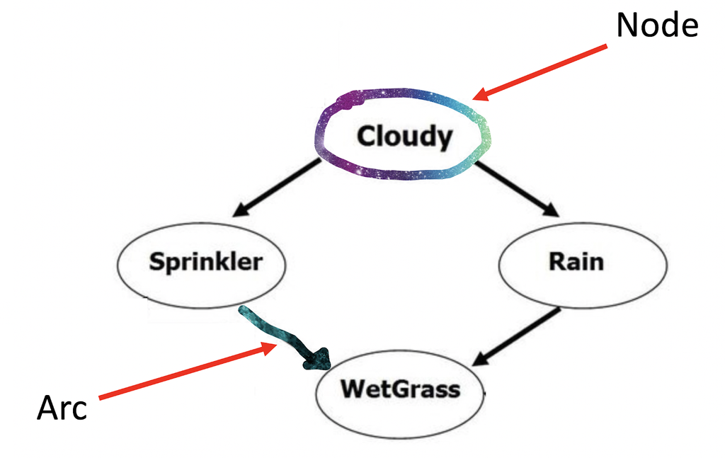

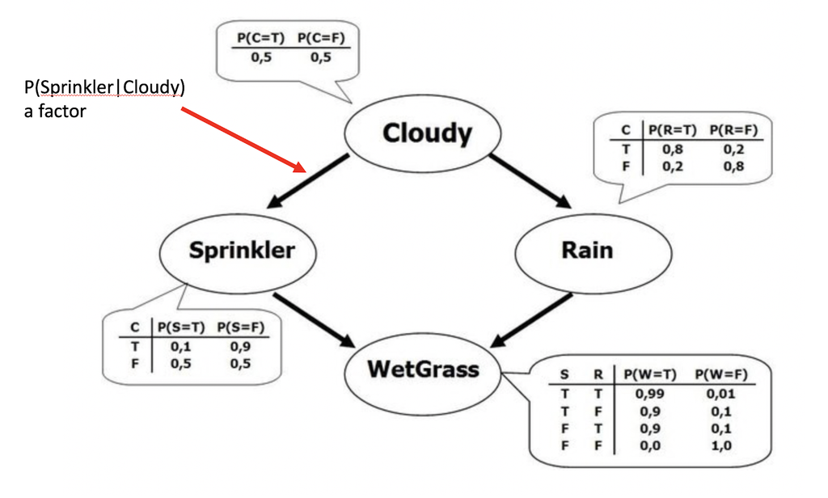

### Lizard Perching Example

Suppose you are a researcher interested in how perch size varies between two closely-related lizard species (*Anolis sangrei* and *Anolis distichus*). An important component of that question is whether or not perch size is conditionally dependent upon species.

Start by looking at your data:

```r
data("lizards")
summary(lizards)
```

```
##       Species      Diameter    Height
##  Sagrei   :164   narrow:252   high:264
##  Distichus:245   wide  :157   low :145
```

Here’s the expected network structure:

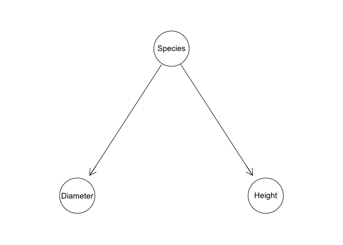

```r
lizmod <- model2network("[Species][Diameter|Species][Height|Species]")
graphviz.plot(lizmod)
```

Now we can fit the network to find the best parameter values using two different methods:

Maximum likelihood estimate

```r
lizfit <- bn.fit(lizmod, lizards, method = 'mle')
lizfit
```

```
##
##   Bayesian network parameters
##
##   Parameters of node Diameter (multinomial distribution)
##
## Conditional probability table:
##
##         Species
## Diameter    Sagrei Distichus
##   narrow 0.7195122 0.5469388
##   wide   0.2804878 0.4530612
##
##   Parameters of node Height (multinomial distribution)
##
## Conditional probability table:
##
##       Species
## Height    Sagrei Distichus
##   high 0.7378049 0.5836735
##   low  0.2621951 0.4163265
##
##   Parameters of node Species (multinomial distribution)
##
## Conditional probability table:
##     Sagrei Distichus
##  0.400978  0.599022
```

Bayesian parameter estimation

```r
lizfit2 <- bn.fit(lizmod, lizards, method = 'bayes')
lizfit2
```

```
##
##   Bayesian network parameters
##
##   Parameters of node Diameter (multinomial distribution)
##
## Conditional probability table:
##
##         Species
## Diameter    Sagrei Distichus
##   narrow 0.7188450 0.5468432
##   wide   0.2811550 0.4531568
##
##   Parameters of node Height (multinomial distribution)
##
## Conditional probability table:
##
##       Species
## Height    Sagrei Distichus
##   high 0.7370821 0.5835031
##   low  0.2629179 0.4164969
##
##   Parameters of node Species (multinomial distribution)
##
## Conditional probability table:
##     Sagrei Distichus
## 0.4012195 0.5987805
```

You should notice that these results are a little different. Why? Because they are two different ways for estimation!

# Bayesian Networks must satisfy the local Markov property

Nodes are conditionally independent of its non-descendents given its parents. For example, the probability of sprinklers going off given it is cloudy and raining, or $P$($Sprinkler$ | $Cloudy$, $Rain$), is equal to the probability of sprinklers going off given it is cloudy, or $P$( $Sprinkler$ | $Cloudy$). From this, we can conclude that rain and sprinkler are not related. This simplifies the joint distributions of the network. It also reduces computation time.

If two variables aren’t conditionally independent, it can’t become a Bayesian Network. There are many different ways to test for this. Today we’ll look at *mutual information* and mention *d-separation*.

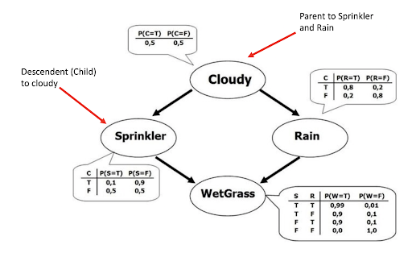

Let’s test our lizard dataset for mutual information, which quantifies how much information you can get from one variable from observation of another variable. We can use the ci.test() function to test whether the variables *height*, *diameter*, and *species* are conditionally independent. In other words, given the species, are height and diameter then independent?

```r
ci.test("Height", "Diameter", "Species", test = "mi", data = lizards)
```

```
##
##  Mutual Information (disc.)
##
## data:  Height ~ Diameter | Species
## mi = 2.0256, df = 2, p-value = 0.3632
## alternative hypothesis: true value is greater than 0
```

```r
dsep(lizfit, 'Height', 'Diameter', 'Species')
```

```
## [1] TRUE
```

# Model learning

Two common types of model learning are **constraint-based** and **score-based**. Constraint based, or inductive causation, is used to find conditionally dependent nodes and link them. It is more accurate than score-based for small sample sizes. Score-based is used to assign a score with some kind of heuristic and optimize the network. It is often faster than constraint based.

### Here’s an example using a damselfish dataset:

Suppose you are a researcher interested in three-spot damselfish (*Dascyllus trimcaculatus*) settlement densities as they relate to available habitat (i.e. empty anemones) as well as survival within different densities. There are many parameters involved (*site*, *pulse* (survival), *observation*, and *density*), and you may want to now how they depend on each other.

```r
data("DamselSettlement")
summary(DamselSettlement)
```

```
##       site         pulse          obs          density
##  Cdina  : 60   Min.   :1.0   Min.   : 1.0   Min.   :  0.00
##  Hin    : 60   1st Qu.:2.0   1st Qu.: 3.0   1st Qu.:  3.50
##  Hout   : 60   Median :3.5   Median : 5.5   Median : 10.70
##  Lin    : 60   Mean   :3.5   Mean   : 5.5   Mean   : 24.19
##  Maa    : 60   3rd Qu.:5.0   3rd Qu.: 8.0   3rd Qu.: 25.30
##  Maha   : 60   Max.   :6.0   Max.   :10.0   Max.   :463.40
##  (Other):240
```

```r
damsel <- DamselSettlement
damsel[,c(2,3)] <- as.numeric(unlist(DamselSettlement[,c(2,3)]))
```

We can find the structure using a score-based, or hill-climbing algorithm:

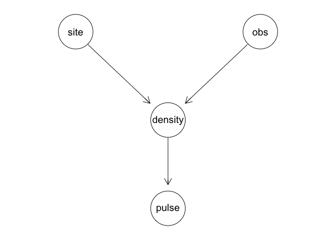

```r
damnet <- hc(damsel)
graphviz.plot(damnet)
```

We can also find the structure using a constraint-based algorithm, or incremental association Markov blanket. Recall that these are better for smaller, discrete datasets.

```r
damnet2 <- iamb(damsel)
```

[output not shown]

(These warnings refer to rounding-type issues)

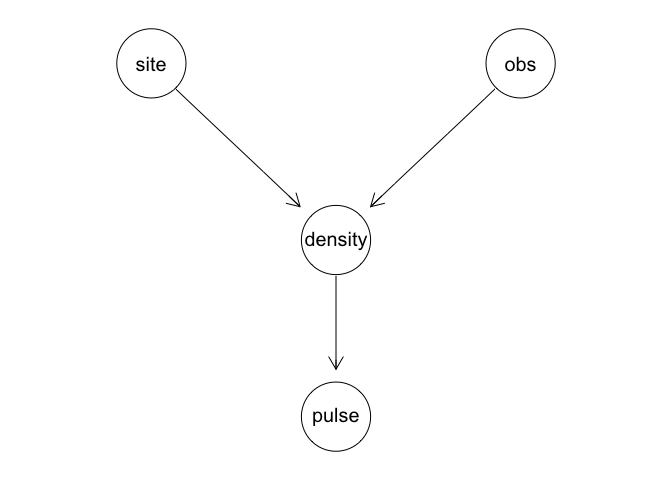

```r
graphviz.plot(damnet2)
```

You get the same result! We can fit the Maximum Likelihood Estimate method to the Bayesian Network. Note: The Bayes method requires a discrete network (for now!)

```r
damfit <- bn.fit(damnet, damsel, method = 'mle')
damfit
```

```
##
##   Bayesian network parameters
##
##   Parameters of node site (multinomial distribution)
##
## Conditional probability table:
##  Cdina   Hin  Hout   Lin   Maa  Maha  OctC  Socc Temae   Vai
##   0.1   0.1   0.1   0.1   0.1   0.1   0.1   0.1   0.1   0.1
##
##   Parameters of node pulse (Gaussian distribution)
##
## Conditional density: pulse | density
## Coefficients:
## (Intercept)      density
## 3.384717723  0.004765286
## Standard deviation of the residuals: 1.696244
##
##   Parameters of node obs (Gaussian distribution)
##
## Conditional density: obs
## Coefficients:
## (Intercept)
##         5.5
## Standard deviation of the residuals: 2.874678
##
##   Parameters of node density (conditional Gaussian distribution)
##
## Conditional density: density | site + obs
## Coefficients:
##                       0           1           2           3           4
## (Intercept)   -4.487778   -4.905556   -4.900000  -17.285556   -3.095556
## obs            2.297475    2.351313    3.555152    7.818889    2.689495
##                       5           6           7           8           9
## (Intercept)    2.586667    3.906667  -10.051222  -13.429889   -1.262222
## obs            9.097576    4.869394    6.915980   12.988040    1.024949
## Standard deviation of the residuals:
##         0          1          2          3          4          5
##  8.344115   8.183630  14.721292  33.100873  16.009208  81.989866
##         6          7          8          9
## 32.061196  26.176080  72.886232   6.981829
## Discrete parents' configurations:
##     site
## 0  Cdina
## 1    Hin
## 2   Hout
## 3    Lin
## 4    Maa
## 5   Maha
## 6   OctC
## 7   Socc
## 8  Temae
## 9    Vai
```

### Let’s take a look at the myxomatosis dataset:

This dataset contains information about a viral titer in blood samples from European rabbits (*Oryctolagus cuniculus*). As a researcher, you may be interested in the conditional relationships between the variables *grade*, *day*, and *titer.*

```r
data("MyxoTiter_sum")
summary(MyxoTiter_sum)
```

```
##      grade            day             titer
##  Min.   :1.000   Min.   : 2.000   Min.   :1.958
##  1st Qu.:3.000   1st Qu.: 4.000   1st Qu.:5.400
##  Median :4.000   Median : 8.000   Median :6.612
##  Mean   :3.604   Mean   : 9.564   Mean   :6.331
##  3rd Qu.:5.000   3rd Qu.:13.000   3rd Qu.:7.489
##  Max.   :5.000   Max.   :28.000   Max.   :9.021
```

We can look at the structure using our two model learning types! First, let’s use the score-based method:

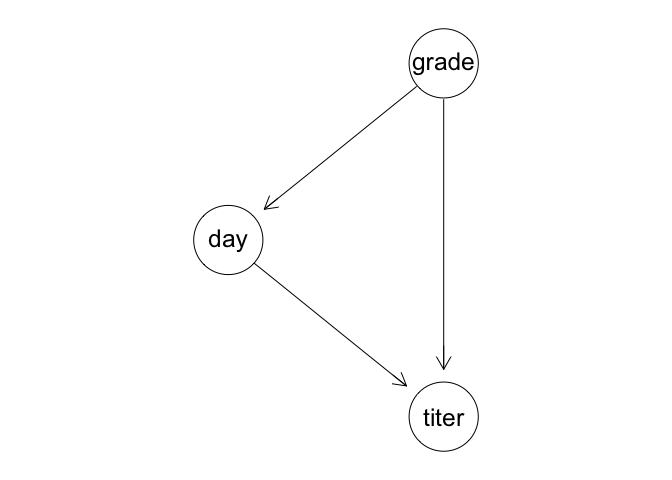

Does this make sense? What if we use the contraint-based method?

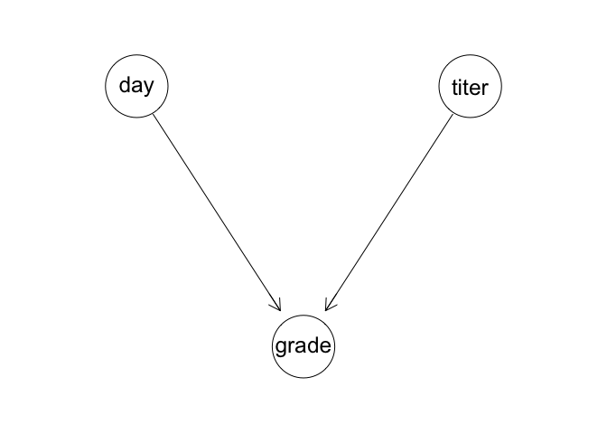

This seems to be a more reasonable representation of the relationships. Let’s visualize the differences:

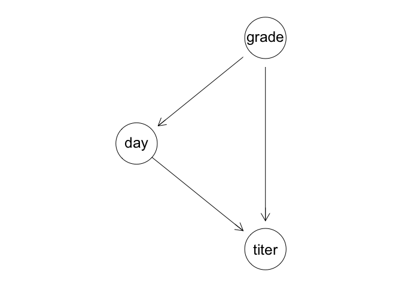

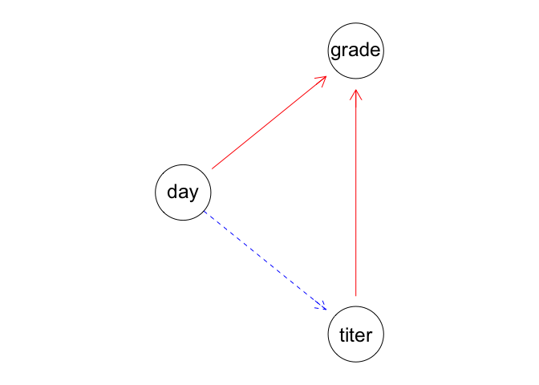

Right now we are just using our own inference to decide on the best model, but we can use the function bnlearn::score() to score the two methods to try and determine the better model.

Score-based model:

```
## [1] -1028.866
```

Constraint-based model:

```
## [1] -1026.812
```

Since the constraint-based method has a better score, we can fit that relationship (that grade is a function of day and titer) to the Bayesian network.

```
##
##   Bayesian network parameters
##
##   Parameters of node grade (Gaussian distribution)
##
## Conditional density: grade | day + titer
## Coefficients:
## (Intercept)          day        titer
##   5.6132230    0.0516698   -0.3954108
## Standard deviation of the residuals: 1.226514
##
##   Parameters of node day (Gaussian distribution)
##
## Conditional density: day
## Coefficients:
## (Intercept)
##    9.563758
## Standard deviation of the residuals: 6.661022
##
##   Parameters of node titer (Gaussian distribution)
##
## Conditional density: titer
## Coefficients:
## (Intercept)
##     6.33102
## Standard deviation of the residuals: 1.516702
```

The Bayesian framework can now be used to predict future events. For example, what is we want to know the probabilty that the viral titer has a concentration of over 5, given it’s been less than three days of infection?

```
## [1] 0.8174204
```

This can be helpful for predicting events!

What about the other way? What’s the probability that the individual has been infected for less than two days, given the grade is more than 3?

```
## [1] 0.0987979
```

Wow! This children nodes can be used to predict the parent nodes!

### Here’s one last example, using a seed dataset:

This dataset comes from a study looking at the disappearance of two seed species (*Polyscias fulva* and *Pseudospondias microcarpa*) in Kibale National Park in Uganda. 9 variables may not seem large, but it can be difficult to map all the conditional relationships between the variables on our own. Let’s use our two model learning algorithms instead!

Let’s start with the score-based method:

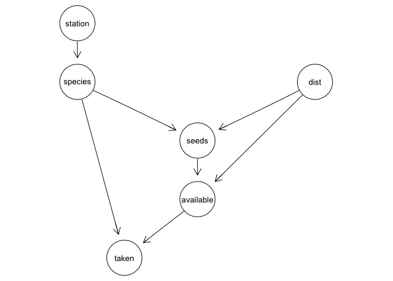

Wow, lot’s of edges! Do you notice any nodes that are mutually independent? Remember that if two variables aren’t conditionally independent, it can’t become a Bayesian Network.

Now let’s use the constraint-based method:

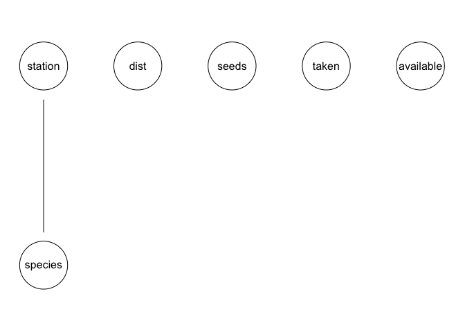

Wow, these are wildly different! By why? Because hill climbing is less sensitive to individual error! Let’s visualize what they did differently:

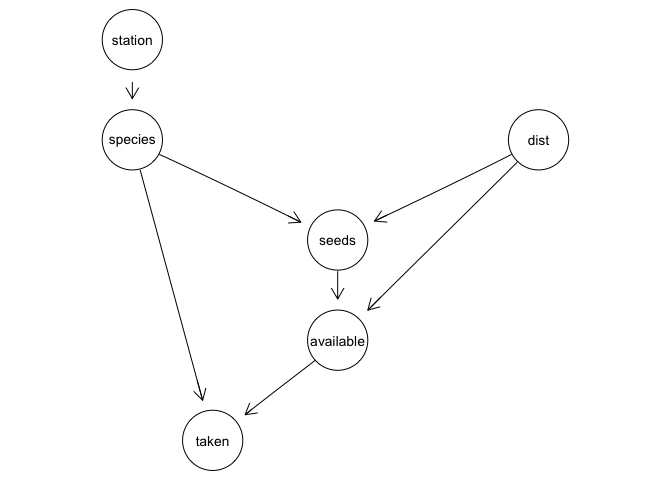

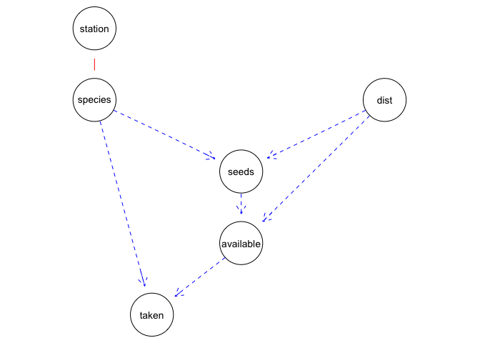

Which one do you think is better? Why? Here are the scores for the two model learning outputs:

Score-based model:

```
## [1] -113709.2
```

Constraint-based model:

```
## Error in bnlearn::score(prednet2, data = pred, type = "bic-cg"): the graph is only partially directed.
```

Whoops! The constraint-based method can’t be scored because there isn’t enough information about the relationships between the nodes. Partially directed networks can’t be scored.

Here is another way to evaluate the model learning techniques using K-fold cross-validation:

Score-based model:

```
##
##   k-fold cross-validation for Bayesian networks
##
##   target network structure:
##    [station][dist][species|station][seeds|dist:species]
##    [available|dist:seeds][taken|species:available]
##   number of folds:                       10
##   loss function:                         Log-Likelihood Loss (cond. Gauss.)
##   expected loss:                         9.408804
```

Constraint-based model:

```
##
##   k-fold cross-validation for Bayesian networks
##
##   target network structure:
##    [dist][species][seeds][taken][available][station|species]
##   number of folds:                       10
##   loss function:                         Log-Likelihood Loss (cond. Gauss.)
##   expected loss:                         10.88629
```

This technique looks at the expected loss of each model, rather than score it using the Bayesian Information Criterion (BIC).

Now we can fit the Bayesian network to our score-based model.

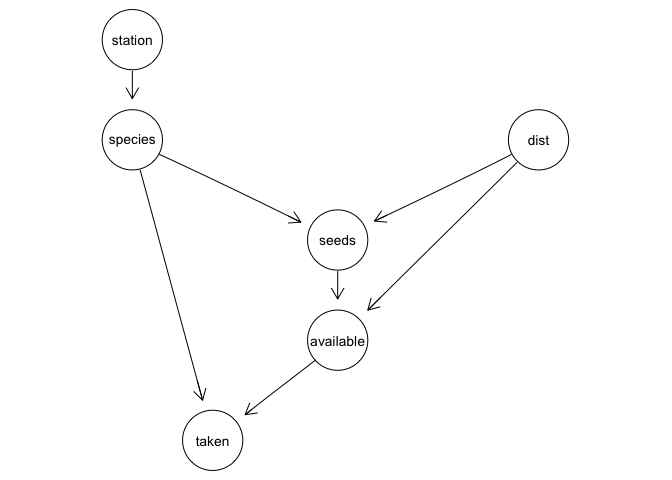

What is the probability that more than one seed was taken given a certain tree species.

```
## [1] 0.07206208
```

### What if we have prior info about a dataset we want to include?

Let’s say we know species influences the number of seeds present….

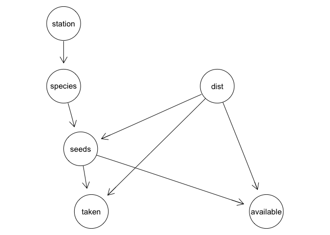

It updates the network!

# Real World Example

This is an example based on a real U.S. Fish and Wildlife Service Bayesian network. It was used to estimate polar bear presence in relation to disease prevalence and habitat quality. This network was entirely based on expert opinion.

First, the researchers set probabilties for disease risk between two categories: *low* and *high*.

```
##      LOW HIGH
## [1,] 0.4  0.6
```

Then, the researchers set probabilities for habitat quality beween two categories: *good* and *bad*.

```
##      GOOD BAD
## [1,]  0.8 0.2
```

Using these probabilities, the researchers were able to create a table of conditional probabilities relating to presence or absence of polar bears (*Ursus maritimus*) based on disease risk and habitat quality. In other words, given the abitat quality and disease risk, what is the probability that an animal is present at that site?

```
## , , Habitat_Quality = GOOD
##
##         Disease
## Presence LOW HIGH
##    TRUE  0.5  0.4
##    FALSE 0.5  0.6
##
## , , Habitat_Quality = BAD
##
##         Disease
## Presence LOW HIGH
##    TRUE  0.3  0.2
##    FALSE 0.7  0.8
```

Using this table of conditional probabilities, we can fit this to a Bayesian network:

```
##
##   Bayesian network parameters
##
##   Parameters of node Disease (multinomial distribution)
##
## Conditional probability table:
##
##  LOW HIGH
##  0.4  0.6
##
##   Parameters of node Habitat_Quality (multinomial distribution)
##
## Conditional probability table:
##
## GOOD  BAD
##  0.8  0.2
##
##   Parameters of node Presence (multinomial distribution)
##
## Conditional probability table:
##
## , , Habitat_Quality = GOOD
##
##         Disease
## Presence LOW HIGH
##    TRUE  0.5  0.4
##    FALSE 0.5  0.6
##
## , , Habitat_Quality = BAD
##
##         Disease
## Presence LOW HIGH
##    TRUE  0.3  0.2
##    FALSE 0.7  0.8
```

And finally, we can visualize the Bayesian network used to describe the conditional probability between nodes.

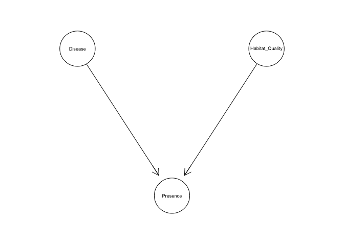

Here is the table that was actually used to inform management decisions regarding the IUCN Red List status for polar bears.

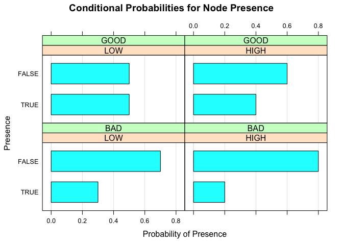

Using the expert-driven information, we can now ask ourselves: how likely is it that polar bears are present, given it’s a poor quality habitat?

```
## [1] 0.2548828
```

# In Conclusion

Bayesian networks are closely tied to Bayes Theorem of conditional probability. They describe the conditional probability, or edges, between variables, or nodes, which can be useful when diagnosing or predicting events.

### Resources

- Aguilera, P. A., et al. “Bayesian networks in environmental modelling.” Environmental Modelling & Software 26.12 (2011): 1376-1388.
- Amstrup, Steven C., Bruce G. Marcot, and David C. Douglas. “A Bayesian network modeling approach to forecasting the 21st century worldwide status of polar bears.” Arctic sea ice decline: observations, projections, mechanisms, and implications 180 (2008): 213-68.
- Charniak, Eugene. “Bayesian networks without tears.” AI magazine 12.4 (1991): 50-50.
- McCann, Robert K., Bruce G. Marcot, and Rick Ellis. “Bayesian belief networks: applications in ecology and natural resource management.” Canadian Journal of Forest Research 36.12 (2006): 3053-3062.
- Milns, Isobel, Colin M. Beale, and V. Anne Smith. “Revealing ecological networks using Bayesian network inference algorithms.” Ecology 91.7 (2010): 1892-1899.
- https://arxiv.org/pdf/0908.3817.pdf
- http://www.bnlearn.com
- https://towardsdatascience.com/introduction-to-bayesian-networks-81031eeed94e

### Challenge Questions

1. See line 104 in the attached R script. What does the closeness of the expected loss imply?
2. For the damsel fish example, why are the networks created by the hill-climbing and incremental association Markov blanket algorithms the same? (hint: compare hc() and iamb() using the dsep() and ci.test() functions!)
3. Why is dsep(damfit, ‘site’, ‘obs’, ‘density’) false? (hint: check out ‘Bayesian Networks without Tears’!)
4. For the seed predation, we had to remove variables associated with date to create the network. What are some way you could still include date? (i.e. is there a way to show dates outside the ‘Date’ class in R?)